# Epigenetic and MZT Biomarker Expression

## Plot methylation-related genes

Plot DNMT3a expression as a function of time and treatment

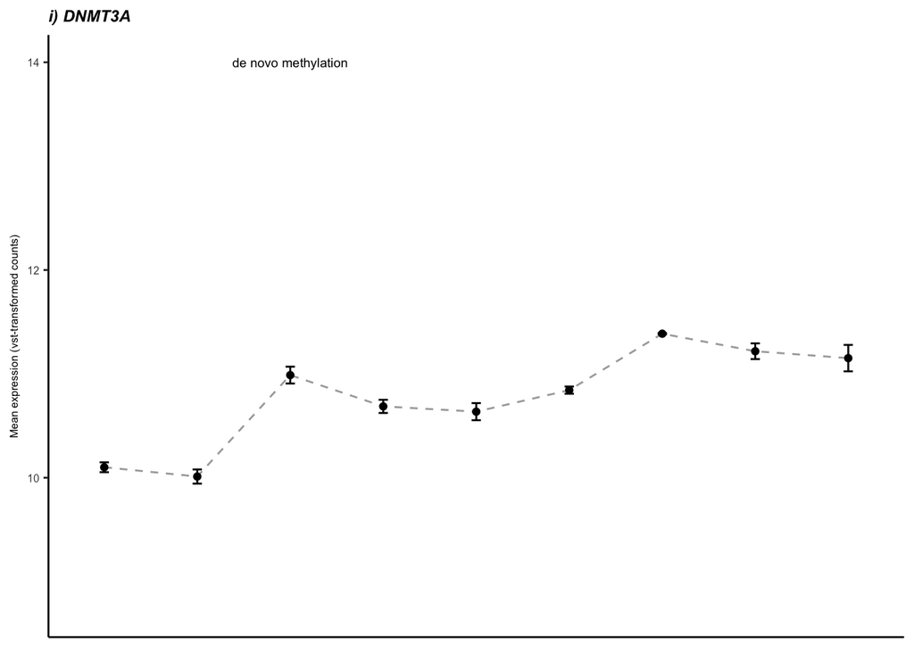

```r
Mcap.DNMT3 <- DNMT3.counts %>% subset(gene_id%in%top_DNMT3) %>%
  ggplot(aes(x=time_point, y=mean, group=gene_id)) +
  geom_errorbar(aes(ymin=mean-sd, ymax=mean+sd), width=.1) +
  geom_line(aes(), lty="dashed", color = "darkgrey") +
  geom_point(aes(), size = 1.5) +
  xlab("Timepoint") +
  ylab(expression(paste("Mean expression (vst-transformed counts)"))) +
  theme_bw() + #Set the background color
  ylim(8.728599, 14) +
  theme(axis.line = element_line(color = 'black'), #Set the axes color
        panel.border = element_blank(), #Set the border
        panel.grid.major = element_blank(), #Set the major gridlines
        panel.grid.minor = element_blank(), #Set the minor gridlines
        plot.background=element_blank(),  #Set the plot background
        axis.title.x=element_blank(), #set x-axis title size
        axis.text.x=element_blank(), #set x-axis label size
        axis.text.y=element_text(size = 6), #set x-axis label size
        axis.title.y=element_text(size = 6), #set x-axis label size
        axis.ticks.x=element_blank(), #No x-label ticks
        legend.text=element_text(size = 6), #Legend text size
        legend.title=element_text(size = 6), #Legend title size
        legend.position=c(0.75, 0.9)) +
  ggtitle("i) DNMT3A") +
  #facet_grid(rows=vars(gene_id), scales="free_y") +
  theme(strip.text.y = element_text(size = 5)) +
  theme(plot.title = element_text(face = 'bold.italic',
                                  size = 9,
                                  hjust = 0)) +
  annotate("text", x = 3, y = 14, label = "de novo methylation", size = 2.5)
Mcap.DNMT3
```

Plot DNMT1 expression as a function of time and treatment

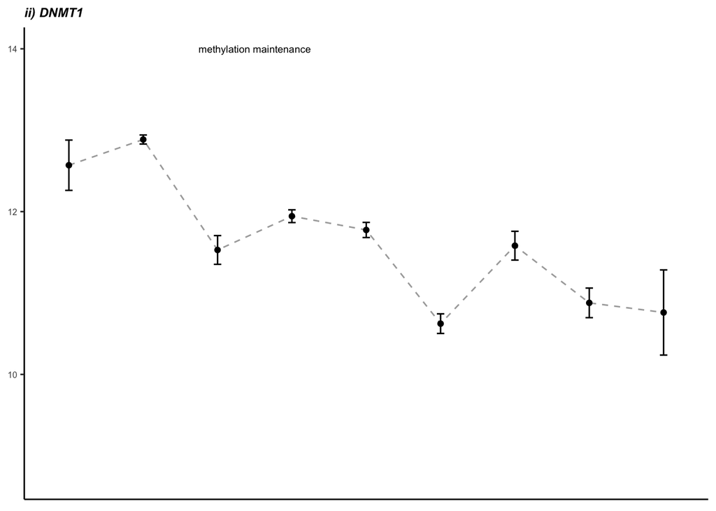

```r
Mcap.DNMT1 <- DNMT1.counts %>% subset(gene_id%in%top_DNMT1) %>%
  ggplot(aes(x=time_point, y=mean, group=gene_id)) +
  geom_errorbar(aes(ymin=mean-sd, ymax=mean+sd), width=.1) +
  geom_line(aes(), lty="dashed", color = "darkgrey") +
  geom_point(aes(), size = 1.5) +
  xlab("Timepoint") +
  ylab(expression(paste("Mean normalized expression"))) +
  theme_bw() + #Set the background color
  ylim(8.728599, 14) +
  theme(axis.line = element_line(color = 'black'), #Set the axes color
        panel.border = element_blank(), #Set the border
        panel.grid.major = element_blank(), #Set the major gridlines
        panel.grid.minor = element_blank(), #Set the minor gridlines
        plot.background=element_blank(),  #Set the plot background
        axis.title.x=element_blank(), #set x-axis title size
        axis.text.x=element_blank(), #set x-axis label size
        axis.text.y=element_text(size = 6), #set x-axis label size
        axis.title.y=element_blank(), #set x-axis label size
        axis.ticks.x=element_blank(), #No x-label ticks
        legend.text=element_text(size = 6), #Legend text size
        legend.title=element_text(size = 6), #Legend title size
        legend.position=c(0.75, 0.9)) +
  ggtitle("ii) DNMT1") +
  #facet_grid(rows=vars(gene_id), scales="free_y") +
  theme(strip.text.y = element_text(size = 5)) +
  theme(plot.title = element_text(face = 'bold.italic',
                                  size = 9,
                                  hjust = 0)) +
  annotate("text", x = 3.5, y = 14, label = "methylation maintenance", size = 2.5)
Mcap.DNMT1
```

Plot TET1 expression as a function of time and treatment

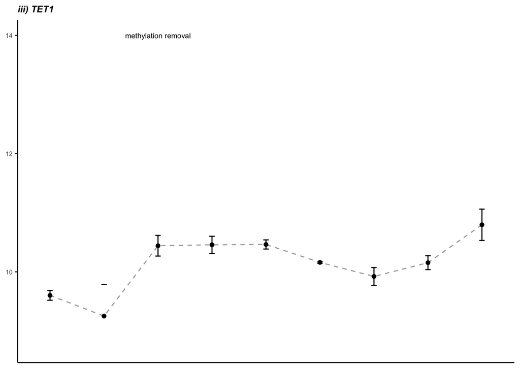

```r
Mcap.TET1 <- ggplot(TET1.counts, aes(x=time_point, y=mean, group=gene_id)) +
  geom_errorbar(aes(ymin=mean-sd, ymax=mean+sd), width=.1) +
  geom_line(aes(), lty="dashed", color = "darkgrey") +
  geom_point(aes(), size = 1.5) +
  xlab("Timepoint") +
  ylab(expression(paste("Mean expression (vst-transformed counts)"))) +
  theme_bw() + #Set the background color
  ylim(8.728599, 14) +
  theme(axis.line = element_line(color = 'black'), #Set the axes color
        panel.border = element_blank(), #Set the border
        panel.grid.major = element_blank(), #Set the major gridlines
        panel.grid.minor = element_blank(), #Set the minor gridlines
        plot.background=element_blank(),  #Set the plot background
        axis.title.x=element_blank(), #set x-axis title size
        axis.text.x=element_blank(), #set x-axis label size
        axis.text.y=element_text(size = 6), #set x-axis label size
        axis.title.y=element_blank(), #set x-axis label size
        axis.ticks.x=element_blank(), #No x-label ticks
        legend.text=element_text(size = 6), #Legend text size
        legend.title=element_text(size = 6), #Legend title size
        legend.position=c(0.75, 0.9)) +
  ggtitle("iii) TET1") +
  #facet_grid(rows=vars(gene_id), scales="free_y") +
  theme(strip.text.y = element_text(size = 5)) +
  theme(plot.title = element_text(face = 'bold.italic',
                                  size = 9,
                                  hjust = 0)) +
  annotate("text", x = 3, y = 14, label = "methylation removal", size = 2.5)
Mcap.TET1
```

Plot MBD2 and MBD3 expression as a function of time and treatment

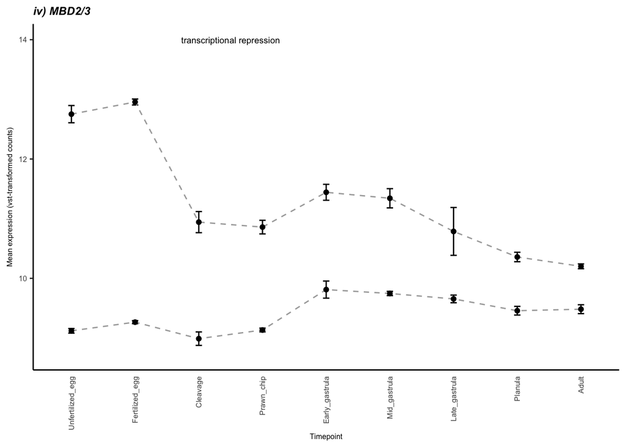

```r
Mcap.MBD2 <- MBD2.counts %>%
  ggplot(aes(x=time_point, y=mean, group=gene_id)) +
  geom_errorbar(aes(ymin=mean-sd, ymax=mean+sd), width=.1) +
  geom_line(lty="dashed", color = "darkgrey") +
  geom_point(aes(), size = 1.5) +
  xlab("Timepoint") +
  ylab(expression(paste("Mean expression (vst-transformed counts)"))) +
  theme_bw() + #Set the background color
  ylim(8.728599, 14) +
  theme(axis.line = element_line(color = 'black'), #Set the axes color
        panel.border = element_blank(), #Set the border
        panel.grid.major = element_blank(), #Set the major gridlines
        panel.grid.minor = element_blank(), #Set the minor gridlines
        plot.background=element_blank(),  #Set the plot background
        axis.title.x=element_text(size = 6), #set x-axis title size
        axis.text.x=element_text(angle = 90, vjust = 0.5, hjust=1, size = 6), #set x-axis label size
        axis.text.y=element_text(size = 6), #set x-axis label size
        axis.title.y=element_text(size = 6), #set x-axis label size
        axis.ticks.x=element_blank(), #No x-label ticks
        legend.text=element_text(size = 6), #Legend text size
        legend.title=element_text(size = 6), #Legend title size
        legend.position=c(0.75, 0.9)) +
  ggtitle("iv) MBD2/3") +
  #facet_grid(rows=vars(gene_id), scales="free_y") +
  theme(strip.text.y = element_text(size = 5)) +
  theme(plot.title = element_text(face = 'bold.italic',
                                  size = 9,
                                  hjust = 0)) +
  annotate("text", x = 3.5, y = 14, label = "transcriptional repression", size = 2.5)
Mcap.MBD2
```

Plot UHRF1 expression as a function of time and treatment

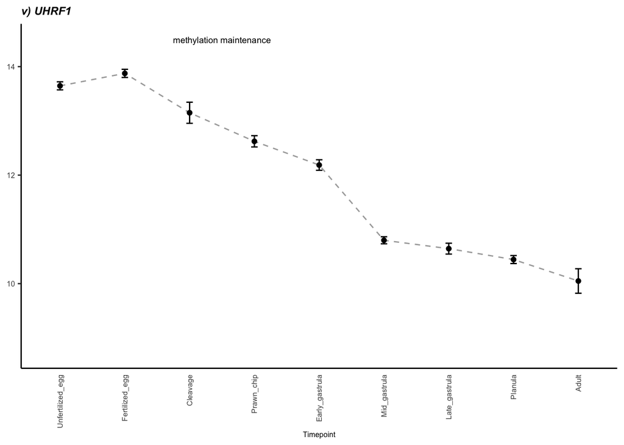

```r
Mcap.UHRF1 <- UHRF1.counts %>% subset(gene_id%in%top_UHRF1) %>% ggplot(aes(x=time_point, y=mean, group=gene_id)) +
  geom_errorbar(aes(ymin=mean-sd, ymax=mean+sd), width=.1) +
  geom_line(lty="dashed", color = "darkgrey") +
  geom_point(aes(), size = 1.5) +
  xlab("Timepoint") +
  ylab(expression(paste("Mean expression (vst-transformed counts)"))) +
  theme_bw() + #Set the background color
  ylim(8.728599, 14.5) +
  theme(axis.line = element_line(color = 'black'), #Set the axes color
        panel.border = element_blank(), #Set the border
        panel.grid.major = element_blank(), #Set the major gridlines
        panel.grid.minor = element_blank(), #Set the minor gridlines
        plot.background=element_blank(),  #Set the plot background
        axis.title.x=element_text(size = 6), #set x-axis title size
        axis.text.x=element_text(angle = 90, vjust = 0.5, hjust=1, size = 6), #set x-axis label size
        axis.text.y=element_text(size = 6), #set x-axis label size
        axis.title.y=element_blank(), #set x-axis label size
        axis.ticks.x=element_blank(), #No x-label ticks
        legend.text=element_text(size = 6), #Legend text size
        legend.title=element_text(size = 6), #Legend title size
        legend.position=c(0.75, 0.85)) +
  ggtitle("v) UHRF1") +
  #facet_grid(rows=vars(gene_id), scales="free_y") +
  theme(strip.text.y = element_text(size = 5)) +
  theme(plot.title = element_text(face = 'bold.italic',
                                  size = 9,
                                  hjust = 0)) +
  annotate("text", x = 3.5, y = 14.5, label = "methylation maintenance", size = 2.5)
Mcap.UHRF1
```

Plot BRG1 expression as a function of time and treatment

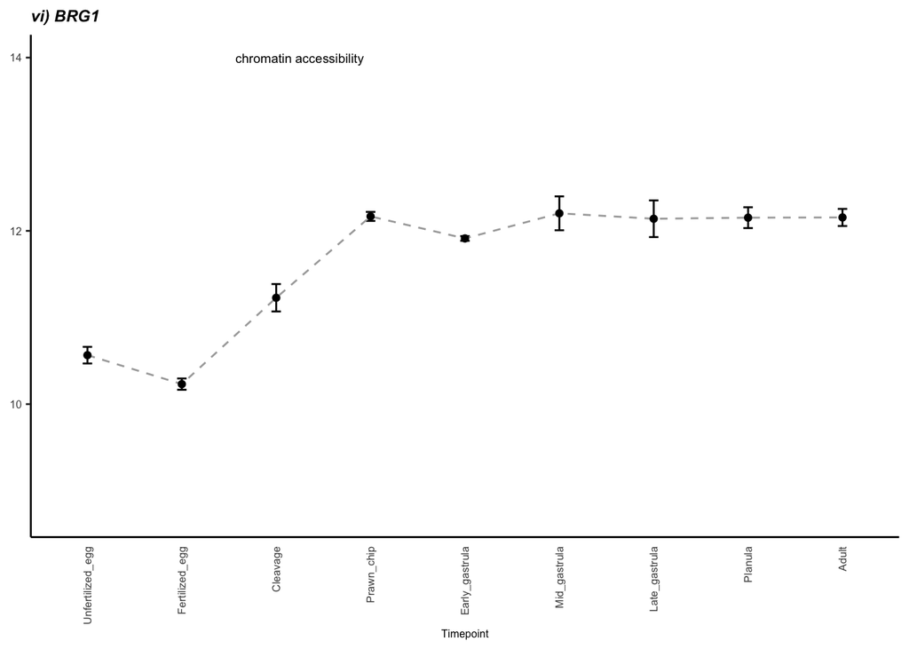

```r
Mcap.BRG1 <- BRG1.counts %>% subset(gene_id%in%top_BRG1) %>%
  ggplot(aes(x=time_point, y=mean, group=gene_id)) +
  geom_errorbar(aes(ymin=mean-sd, ymax=mean+sd), width=.1) +
  geom_line(lty="dashed", color = "darkgrey") +
  geom_point(aes(), size = 1.5) +
  xlab("Timepoint") +
  ylab(expression(paste("Mean expression (vst-transformed counts)"))) +
  theme_bw() + #Set the background color
  ylim(8.728599, 14) +
  theme(axis.line = element_line(color = 'black'), #Set the axes color
        panel.border = element_blank(), #Set the border
        panel.grid.major = element_blank(), #Set the major gridlines
        panel.grid.minor = element_blank(), #Set the minor gridlines
        plot.background=element_blank(),  #Set the plot background
        axis.title.x=element_text(size = 6), #set x-axis title size
        axis.text.x=element_text(angle = 90, vjust = 0.5, hjust=1, size = 6), #set x-axis label size
        axis.text.y=element_text(size = 6), #set x-axis label size
        axis.title.y=element_blank(), #set x-axis label size
        axis.ticks.x=element_blank(), #No x-label ticks
        legend.text=element_text(size = 6), #Legend text size
        legend.title=element_text(size = 6), #Legend title size
        legend.position = c(0.75, 0.9)) +
  #guides(shape=guide_legend(ncol=2)) +
  ggtitle("vi) BRG1") +
  #facet_grid(rows=vars(gene_id), scales="free_y") +
  theme(strip.text.y = element_text(size = 5)) +
  theme(plot.title = element_text(face = 'bold.italic',
                                  size = 9,
                                  hjust = 0)) +
  annotate("text", x = 3.25, y = 14, label = "chromatin accessibility", size = 2.5)
Mcap.BRG1
```

Compile plots into single figure and save

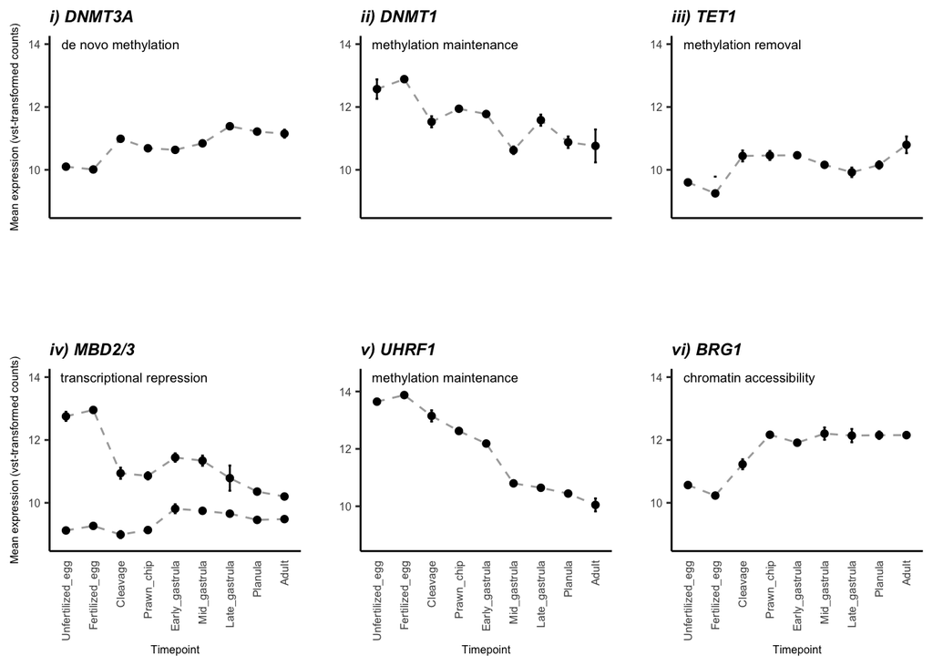

```r
Fig.7 <- cowplot::plot_grid(Mcap.DNMT3, Mcap.DNMT1, Mcap.TET1, Mcap.MBD2, Mcap.UHRF1, Mcap.BRG1, align = "vh", ncol = 3)
Fig.7
```

```r
ggsave("2b-Epi-MZT-Enzyme-Expression/Output/Fig7-Mcap-Dev-Epi-Expression.pdf", Fig.7, width=7, height=5)
```

## Plot MZT biomarkers

Plot CyclinB expression as a function of time and treatment

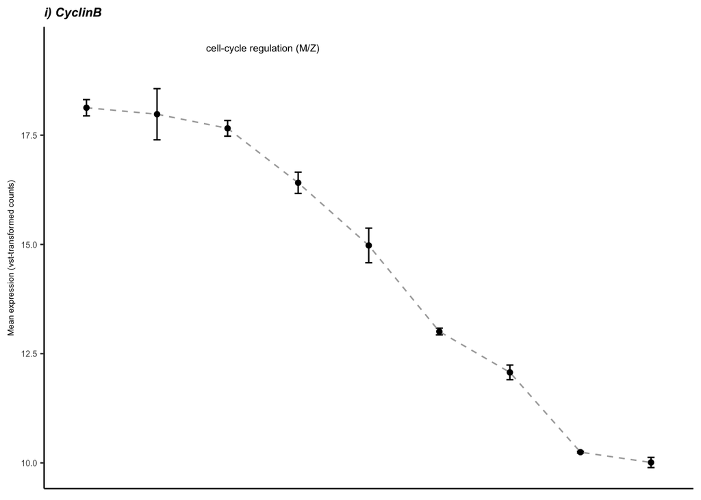

```r
Mcap.CyclinB <- CyclinB.counts %>% subset(gene_id%in%top_CyclinB) %>%
  ggplot(aes(x=time_point, y=mean, group=gene_id)) +
  geom_errorbar(aes(ymin=mean-sd, ymax=mean+sd), width=.1) +
  geom_line(lty="dashed", color = "darkgrey") +
  geom_point(aes(), size = 1.5) +
  xlab("Timepoint") +
  ylab(expression(paste("Mean expression (vst-transformed counts)"))) +
  theme_bw() + #Set the background color
  #ylim(8,19) +
    theme(axis.line = element_line(color = 'black'), #Set the axes color
        panel.border = element_blank(), #Set the border
        panel.grid.major = element_blank(), #Set the major gridlines
        panel.grid.minor = element_blank(), #Set the minor gridlines
        plot.background=element_blank(),  #Set the plot background
        axis.title.x=element_blank(), #set x-axis title size
        axis.text.x=element_blank(), #set x-axis label size
        axis.text.y=element_text(size = 6), #set x-axis label size
        axis.title.y=element_text(size = 6), #set x-axis label size
        axis.ticks.x=element_blank(), #No x-label ticks
        legend.title=element_text(size = 6), #Legend text size
        legend.text=element_text(size = 6), #Legend text size
        legend.position = c(0.75, 0.9)) +
  ggtitle("i) CyclinB") +
  #facet_grid(rows=vars(gene_id), scales="free_y") +
  theme(strip.text.y = element_text(size = 5)) +
  theme(plot.title = element_text(face = 'bold.italic',
                                  size = 9,
                                  hjust = 0)) +
  annotate("text", x = 3.5, y = 19.5, label = "cell-cycle regulation (M/Z)", size = 2.5)
Mcap.CyclinB
```

Plot SMAUG expression as a function of time and treatment

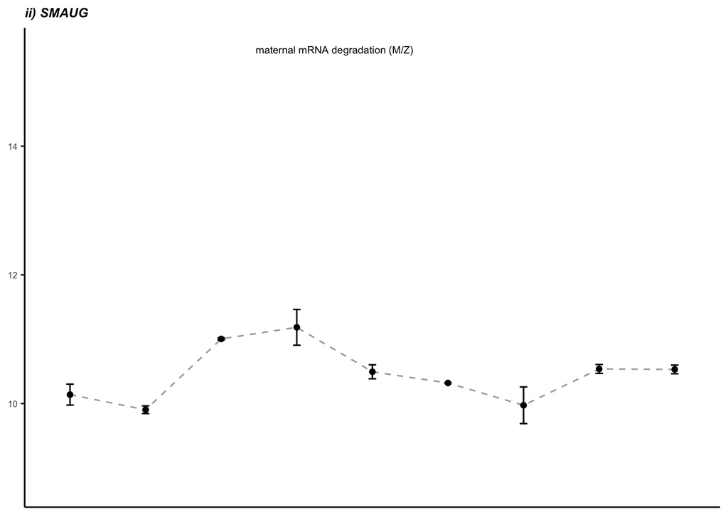

```r
Mcap.SMG <- SMG.counts %>% subset(gene_id%in%top_SMG) %>% ggplot(aes(x=time_point, y=mean, group=gene_id)) +
  geom_errorbar(aes(ymin=mean-sd, ymax=mean+sd), width=.1) +
  geom_line(aes(), lty="dashed", color = "darkgrey") +
  geom_point(aes(), size = 1.5) +
  xlab("Timepoint") +
  ylab(expression(paste("Mean expression (vst-transformed counts)"))) +
  theme_bw() + #Set the background color
  ylim(8.728599, 15.5) +
  theme(axis.line = element_line(color = 'black'), #Set the axes color
        panel.border = element_blank(), #Set the border
        panel.grid.major = element_blank(), #Set the major gridlines
        panel.grid.minor = element_blank(), #Set the minor gridlines
        plot.background=element_blank(),  #Set the plot background
        axis.title.x=element_blank(), #set x-axis title size
        axis.text.x=element_blank(), #set x-axis label size
        axis.text.y=element_text(size = 6), #set x-axis label size
        axis.title.y=element_blank(), #set x-axis label size
        axis.ticks.x=element_blank(), #No x-label ticks
        legend.text=element_text(size = 6), #Legend text size
        legend.title=element_text(size = 6), #Legend text size
        legend.position = c(0.85, 0.9)) +
  ggtitle("ii) SMAUG") +
  #facet_grid(rows=vars(gene_id), scales="free_y") +
  theme(strip.text.y = element_text(size = 5)) +
  theme(plot.title = element_text(face = 'bold.italic',
                                  size = 9,
                                  hjust = 0)) +
  annotate("text", x = 4.5, y = 15.5, label = "maternal mRNA degradation (M/Z)", size = 2.5)
Mcap.SMG
```

Plot KAISO expression as a function of time and treatment

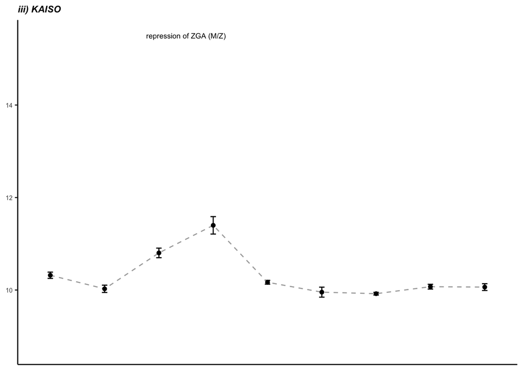

```r
Mcap.KAISO <- KAISO.counts %>% subset(gene_id%in%top_KAISO) %>%
  ggplot(aes(x=time_point, y=mean, group=gene_id)) +
  geom_errorbar(aes(ymin=mean-sd, ymax=mean+sd), width=.1) +
  geom_line(aes(), lty="dashed", color = "darkgrey") +
  geom_point(aes(), size = 1.5) +
  xlab("Timepoint") +
  ylab(expression(paste("Mean expression (vst-transformed counts)"))) +
  theme_bw() + #Set the background color
  ylim(8.728599, 15.5) +
  theme(axis.line = element_line(color = 'black'), #Set the axes color
        panel.border = element_blank(), #Set the border
        panel.grid.major = element_blank(), #Set the major gridlines
        panel.grid.minor = element_blank(), #Set the minor gridlines
        plot.background=element_blank(),  #Set the plot background
        axis.title.x=element_blank(), #set x-axis title size
        axis.text.x=element_blank(), #set x-axis label size
        axis.text.y=element_text(size = 6), #set x-axis label size
        axis.title.y=element_blank(), #set x-axis label size
        axis.ticks.x=element_blank(), #No x-label ticks
        legend.text=element_text(size = 6), #Legend text size
        legend.title=element_text(size = 6), #Legend text size
        legend.position = c(0.75, 0.9)) +
  ggtitle("iii) KAISO") +
  #facet_grid(rows=vars(gene_id), scales="free_y") +
  theme(strip.text.y = element_text(size = 5)) +
  theme(plot.title = element_text(face = 'bold.italic',
                                  size = 9,
                                  hjust = 0)) +
  annotate("text", x = 3.5, y = 15.5, label = "repression of ZGA (M/Z)", size = 2.5)
Mcap.KAISO
```

Plot SOX2 expression as a function of time and treatment

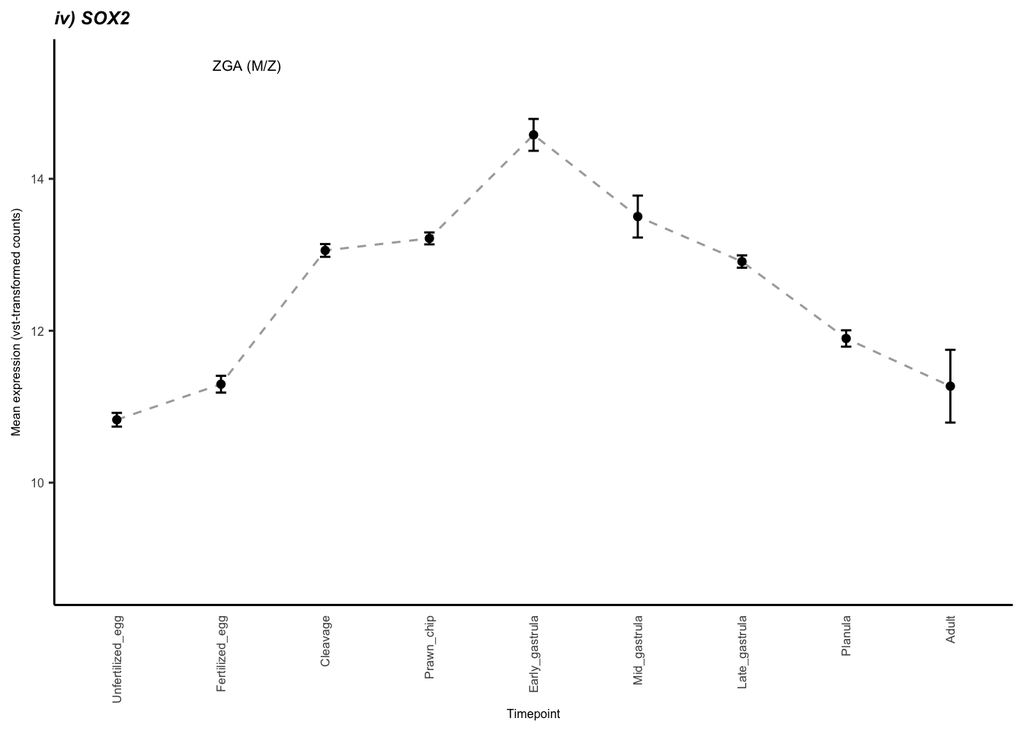

```r
Mcap.SOX2 <- SOX2.counts %>% subset(gene_id%in%top_SOX2) %>%
  ggplot(aes(x=time_point, y=mean, group=gene_id)) +
  geom_errorbar(aes(ymin=mean-sd, ymax=mean+sd), width=.1) +
  geom_line(lty="dashed", color = "darkgrey") +
  geom_point(aes(), size = 1.5) +
  xlab("Timepoint") +
  ylab(expression(paste("Mean expression (vst-transformed counts)"))) +
  theme_bw() + #Set the background color
  ylim(8.728599, 15.5) +
  theme(axis.line = element_line(color = 'black'), #Set the axes color
        panel.border = element_blank(), #Set the border
        panel.grid.major = element_blank(), #Set the major gridlines
        panel.grid.minor = element_blank(), #Set the minor gridlines
        plot.background=element_blank(),  #Set the plot background
        axis.title.x=element_text(size = 6), #set x-axis title size
        axis.text.x=element_text(angle = 90, vjust = 0.5, hjust=1, size = 6), #set x-axis label size
        axis.text.y=element_text(size = 6), #set x-axis label size
        axis.title.y=element_text(size = 6), #set y-axis title size
        axis.ticks.x=element_blank(), #No x-label ticks
        legend.text=element_text(size = 6), #Legend text size
        legend.title=element_text(size = 6), #Legend text size
        legend.position = c(0.75, 0.9)) +
  ggtitle("iv) SOX2") +
  #facet_grid(rows=vars(gene_id), scales="free_y") +
  theme(strip.text.y = element_text(size = 5)) +
  theme(plot.title = element_text(face = 'bold.italic',
                                  size = 9,
                                  hjust = 0)) +
  annotate("text", x = 2.25, y = 15.5, label = "ZGA (M/Z)", size = 2.5)
Mcap.SOX2
```

Plot WNT8 expression as a function of time and treatment

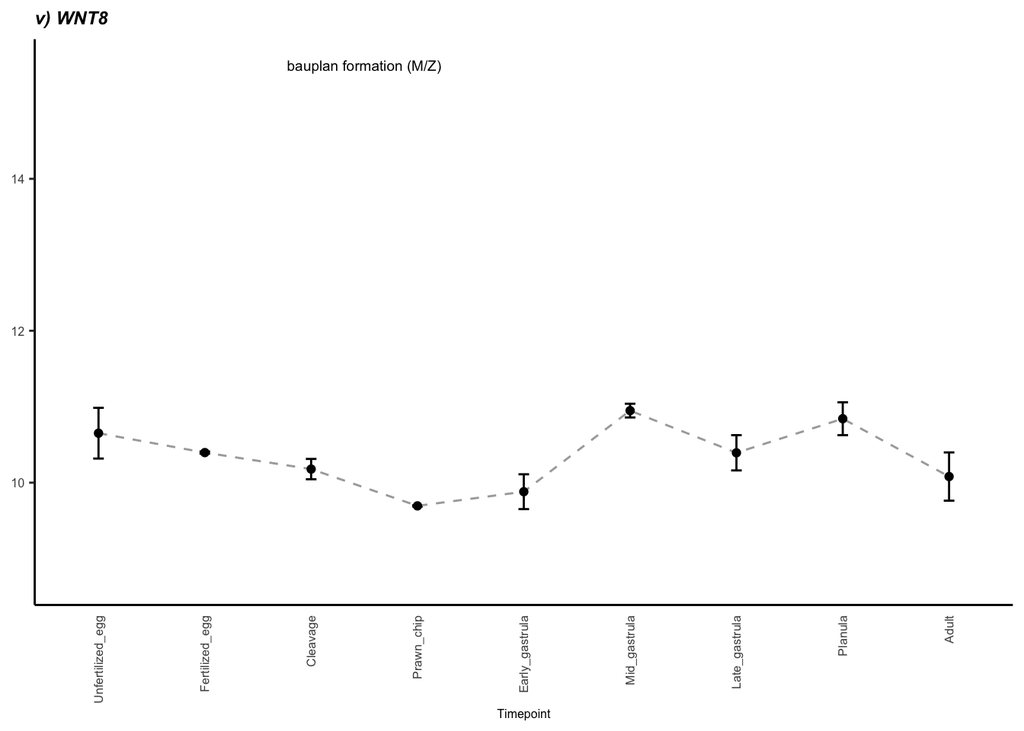

```r
Mcap.WNT8 <- WNT8.counts %>% subset(gene_id%in%top_WNT8) %>%
  ggplot(aes(x=time_point, y=mean, group=gene_id)) +
  geom_errorbar(aes(ymin=mean-sd, ymax=mean+sd), width=.1) +
  geom_line(lty="dashed", color = "darkgrey") +
  geom_point(aes(), size = 1.5) +
  xlab("Timepoint") +
  ylab(expression(paste("Mean expression (vst-transformed counts)"))) +
  theme_bw() + #Set the background color
  ylim(8.728599, 15.5) +
  theme(axis.line = element_line(color = 'black'), #Set the axes color
        panel.border = element_blank(), #Set the border
        panel.grid.major = element_blank(), #Set the major gridlines
        panel.grid.minor = element_blank(), #Set the minor gridlines
        plot.background=element_blank(),  #Set the plot background
        axis.title.x=element_text(size = 6), #set x-axis title size
        axis.text.x=element_text(angle = 90, vjust = 0.5, hjust=1, size = 6), #set x-axis label size
        axis.text.y=element_text(size = 6), #set x-axis label size
        axis.title.y=element_blank(), #set x-axis label size
        axis.ticks.x=element_blank(), #No x-label ticks
        legend.text=element_text(size = 6), #Legend text size
        legend.title=element_text(size = 6), #Legend text size
        legend.position = c(0.75, 0.9),
        legend.spacing.y = unit(0.01, 'cm')) +
  #guides(shape=guide_legend(ncol=2)) +
  ggtitle("v) WNT8") +
  #facet_grid(rows=vars(gene_id), scales="free_y") +
  theme(strip.text.y = element_text(size = 5)) +
  theme(plot.title = element_text(face = 'bold.italic',
                                  size = 9,
                                  hjust = 0)) +
  annotate("text", x = 3.5, y = 15.5, label = "bauplan formation (M/Z)", size = 2.5)
Mcap.WNT8
```

Plot TBXT expression as a function of time and treatment

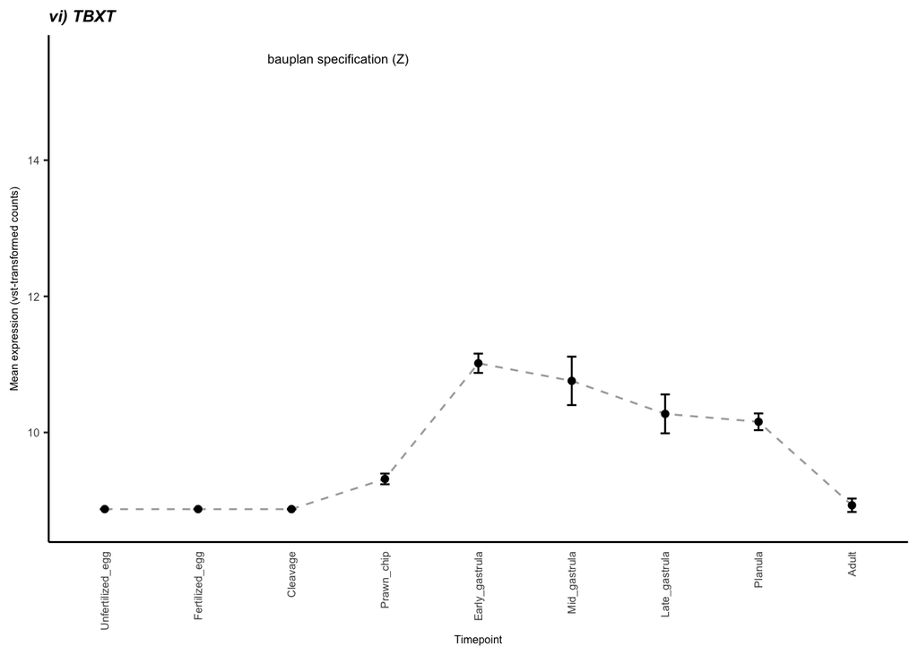

```r
Mcap.TBXT <- TBXT.counts %>% subset(gene_id%in%top_TBXT) %>%
  ggplot(aes(x=time_point, y=mean, group=gene_id)) +
  geom_errorbar(aes(ymin=mean-sd, ymax=mean+sd), width=.1) +
  geom_line(lty="dashed", color = "darkgrey") +
  geom_point(aes(), size = 1.5) +
  xlab("Timepoint") +
  ylab(expression(paste("Mean expression (vst-transformed counts)"))) +
  theme_bw() + #Set the background color
  ylim(8.728599, 15.5) +
    theme(axis.line = element_line(color = 'black'), #Set the axes color
        panel.border = element_blank(), #Set the border
        panel.grid.major = element_blank(), #Set the major gridlines
        panel.grid.minor = element_blank(), #Set the minor gridlines
        plot.background=element_blank(),  #Set the plot background
        axis.title.x=element_text(size = 6), #set x-axis title size
        axis.text.x=element_text(angle = 90, vjust = 0.5, hjust=1, size = 6), #set x-axis label size
        axis.text.y=element_text(size = 6), #set x-axis label size
        axis.title.y=element_text(size = 6), #set x-axis label size
        axis.ticks.x=element_blank(), #No x-label ticks
        legend.text=element_text(size = 6), #Legend text size
        legend.title=element_blank(), #Legend text size
        legend.position = c(0.85, 0.85)) +
  ggtitle("vi) TBXT") +
  #facet_grid(rows=vars(gene_id), scales="free_y") +
  theme(strip.text.y = element_text(size = 5)) +
  theme(plot.title = element_text(face = 'bold.italic',
                                  size = 9,
                                  hjust = 0)) +
  annotate("text", x = 3.5, y = 15.5, label = "bauplan specification (Z)", size = 2.5)
Mcap.TBXT
```

Compile plots into single figure and save

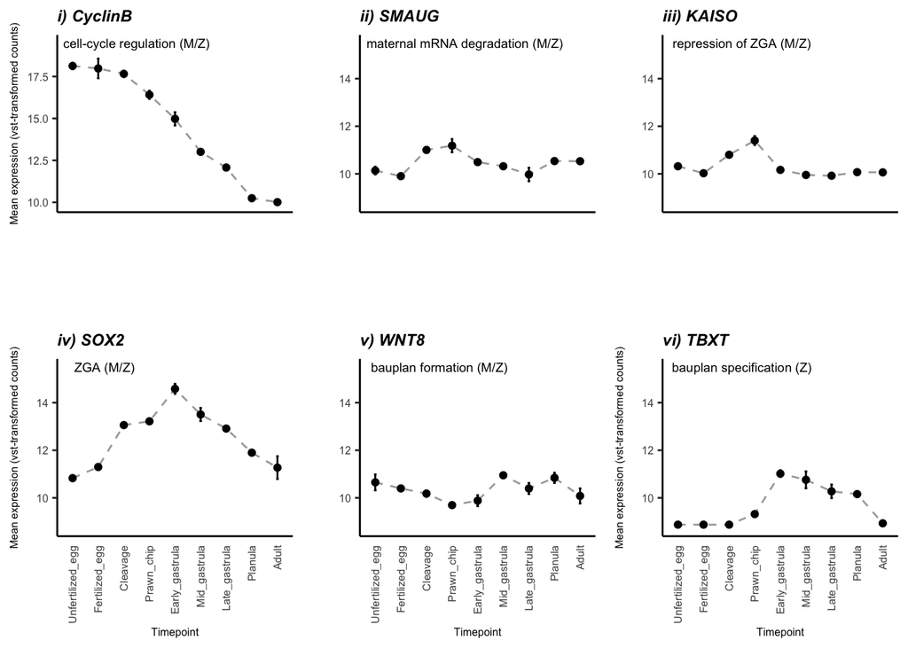

```r
Fig.6 <- cowplot::plot_grid(Mcap.CyclinB, Mcap.SMG, Mcap.KAISO, Mcap.SOX2, Mcap.WNT8, Mcap.TBXT, align = "vh", ncol = 3)
Fig.6
```

```r
ggsave("2b-Epi-MZT-Enzyme-Expression/Output/Fig6-Mcap-Dev-MZT-Expression.pdf", Fig.6, width=7, height=5)
```

# Run differential expression analysis to see if any biomarkers are differentially expressed

Run differential expression test using a Wald model.

```r
DEG_dev <- DESeq(gdds_dev) #run differential expression test by group using the Wald model
```

Make a list of biomarkers to look for:

```r
Epi.markers <- c(top_DNMT1, top_DNMT3, TET1.counts$gene_id, MBD3.counts$gene_id, top_UHRF1, top_BRG1)

Dev.markers <- c(top_CyclinB, top_SMG, top_KAISO, top_SOX2, top_WNT8, top_TBXT)
```

Look for differential expression of biomarkers

```r
DESeq.results.fe_vs_ue <-  results(DEG_dev, name="time_point_Fertilized_egg_vs_Unfertilized_egg")
DESeq.results.fe_vs_ue <- as.data.frame(DESeq.results.fe_vs_ue)
DESeq.results.fe_vs_ue$contrast <- c("Fertilized_egg_vs_Unfertilized_egg")
DESeq.results.fe_vs_ue$gene_id <-  rownames(DESeq.results.fe_vs_ue)
fe_vs_ue.DEGs <- filter(DESeq.results.fe_vs_ue, padj<0.05)
nrow(fe_vs_ue.DEGs) #N DEGs
```

```
## [1] 2151
```

```r
Epi.DEGs.fe_vs_ue <- filter(DESeq.results.fe_vs_ue, gene_id%in%Epi.markers, padj<0.05, log2FoldChange>1 | log2FoldChange<(-1))
Dev.DEGs.fe_vs_ue <- filter(DESeq.results.fe_vs_ue, gene_id%in%Dev.markers, padj<0.05, log2FoldChange>1 | log2FoldChange<(-1))

DESeq.results.clvg_vs_fe <-  results(DEG_dev, contrast= c("time_point","Cleavage","Fertilized_egg"))
DESeq.results.clvg_vs_fe <- as.data.frame(DESeq.results.clvg_vs_fe)
DESeq.results.clvg_vs_fe$contrast <- c("Cleavage_vs_Fertilized_egg")
DESeq.results.clvg_vs_fe$gene_id <-  rownames(DESeq.results.clvg_vs_fe)
clvg_vs_fe.DEGs <- filter(DESeq.results.clvg_vs_fe, padj<0.05)
nrow(clvg_vs_fe.DEGs) #N DEGs
```

```
## [1] 9326
```

```r
Epi.DEGs.clvg_vs_fe <- filter(DESeq.results.clvg_vs_fe, gene_id%in%Epi.markers, padj<0.05, log2FoldChange>1 | log2FoldChange<(-1))
Dev.DEGs.clvg_vs_fe <- filter(DESeq.results.clvg_vs_fe, gene_id%in%Dev.markers, padj<0.05, log2FoldChange>1 | log2FoldChange<(-1))

DESeq.results.pc_vs_clvg <-  results(DEG_dev, contrast= c("time_point","Prawn_chip","Cleavage"))
DESeq.results.pc_vs_clvg <- as.data.frame(DESeq.results.pc_vs_clvg)
DESeq.results.pc_vs_clvg$contrast <- c("Prawn_chip_vs_Cleavage")
DESeq.results.pc_vs_clvg$gene_id <-  rownames(DESeq.results.pc_vs_clvg)
pc_vs_clvg.DEGs <- filter(DESeq.results.pc_vs_clvg, padj<0.05)
nrow(pc_vs_clvg.DEGs) #N DEGs
```

```
## [1] 8409
```

```r
Epi.DEGs.pc_vs_clvg <- filter(DESeq.results.pc_vs_clvg, gene_id%in%Epi.markers, padj<0.05, log2FoldChange>1 | log2FoldChange<(-1))
Dev.DEGs.pc_vs_clvg <- filter(DESeq.results.pc_vs_clvg, gene_id%in%Dev.markers, padj<0.05, log2FoldChange>1 | log2FoldChange<(-1))

DESeq.results.eg_vs_pc <-  results(DEG_dev, contrast= c("time_point", "Early_gastrula","Prawn_chip"))
DESeq.results.eg_vs_pc <- as.data.frame(DESeq.results.eg_vs_pc)
DESeq.results.eg_vs_pc$contrast <- c("Early_gastrula_vs_Prawn_chip")
DESeq.results.eg_vs_pc$gene_id <-  rownames(DESeq.results.eg_vs_pc)
eg_vs_pc.DEGs <- filter(DESeq.results.eg_vs_pc, padj<0.05)
nrow(eg_vs_pc.DEGs) #N DEGs
```

```
## [1] 9488
```

```r
Epi.DEGs.eg_vs_pc <- filter(DESeq.results.eg_vs_pc, gene_id%in%Epi.markers, padj<0.05, log2FoldChange>1 | log2FoldChange<(-1))
Dev.DEGs.eg_vs_pc <- filter(DESeq.results.eg_vs_pc, gene_id%in%Dev.markers, padj<0.05, log2FoldChange>1 | log2FoldChange<(-1))

DESeq.results.mg_vs_eg <-  results(DEG_dev, contrast= c("time_point", "Mid_gastrula", "Early_gastrula"))
DESeq.results.mg_vs_eg <- as.data.frame(DESeq.results.mg_vs_eg)
DESeq.results.mg_vs_eg$contrast <- c("Mid_gastrula_vs_Early_gastrula")
DESeq.results.mg_vs_eg$gene_id <-  rownames(DESeq.results.mg_vs_eg)
mg_vs_eg.DEGs <- filter(DESeq.results.mg_vs_eg, padj<0.05)
nrow(mg_vs_eg.DEGs) #N DEGs
```

```
## [1] 7136
```

```r
Epi.DEGs.mg_vs_eg <- filter(DESeq.results.mg_vs_eg, gene_id%in%Epi.markers, padj<0.05, log2FoldChange>1 | log2FoldChange<(-1))
Dev.DEGs.mg_vs_eg <- filter(DESeq.results.mg_vs_eg, gene_id%in%Dev.markers, padj<0.05, log2FoldChange>1 | log2FoldChange<(-1))

DESeq.results.lg_vs_mg <-  results(DEG_dev, contrast= c("time_point","Late_gastrula","Mid_gastrula"))
DESeq.results.lg_vs_mg <- as.data.frame(DESeq.results.lg_vs_mg)
DESeq.results.lg_vs_mg$contrast <- c("Late_gastrula_vs_Mid_gastrula")
DESeq.results.lg_vs_mg$gene_id <-  rownames(DESeq.results.lg_vs_mg)
lg_vs_mg.DEGs <- filter(DESeq.results.lg_vs_mg, padj<0.05)
nrow(lg_vs_mg.DEGs) #N DEGs
```

```
## [1] 4336
```

```r
Epi.DEGs.lg_vs_mg <- filter(DESeq.results.lg_vs_mg, gene_id%in%Epi.markers, padj<0.05, log2FoldChange>1 | log2FoldChange<(-1))
Dev.DEGs.lg_vs_mg <- filter(DESeq.results.lg_vs_mg, gene_id%in%Dev.markers, padj<0.05, log2FoldChange>1 | log2FoldChange<(-1))

DESeq.results.pln_vs_lg <-  results(DEG_dev, contrast= c("time_point", "Planula", "Late_gastrula"))
DESeq.results.pln_vs_lg <- as.data.frame(DESeq.results.pln_vs_lg)
DESeq.results.pln_vs_lg$contrast <- c("Planula_vs_Late_gastrula")
DESeq.results.pln_vs_lg$gene_id <-  rownames(DESeq.results.pln_vs_lg)
pln_vs_lg.DEGs <- filter(DESeq.results.pln_vs_lg, padj<0.05)
nrow(pln_vs_lg.DEGs) #N DEGs
```

```
## [1] 4347
```

```r
Epi.DEGs.pln_vs_lg <- filter(DESeq.results.pln_vs_lg, gene_id%in%Epi.markers, padj<0.05, log2FoldChange>1 | log2FoldChange<(-1))
Dev.DEGs.pln_vs_lg <- filter(DESeq.results.pln_vs_lg, gene_id%in%Dev.markers, padj<0.05, log2FoldChange>1 | log2FoldChange<(-1))

DESeq.results.adult_vs_pln <-  results(DEG_dev, contrast= c("time_point", "Adult","Planula"))
DESeq.results.adult_vs_pln <- as.data.frame(DESeq.results.adult_vs_pln)
DESeq.results.adult_vs_pln$contrast <- c("Adult_vs_Planula")
DESeq.results.adult_vs_pln$gene_id <-  rownames(DESeq.results.adult_vs_pln)
adult_vs_pln.DEGs <- filter(DESeq.results.adult_vs_pln, padj<0.05)
nrow(adult_vs_pln.DEGs) #N DEGs
```

```
## [1] 6899
```

```r
Epi.DEGs.adult_vs_pln <- filter(DESeq.results.adult_vs_pln, gene_id%in%Epi.markers, padj<0.05, log2FoldChange>1 | log2FoldChange<(-1))
Dev.DEGs.adult_vs_pln <- filter(DESeq.results.adult_vs_pln, gene_id%in%Dev.markers, padj<0.05, log2FoldChange>1 | log2FoldChange<(-1))
```

Bind results. Add enzyme names for biomarker files.

```r
#all
all_DEGs <- bind_rows(fe_vs_ue.DEGs, clvg_vs_fe.DEGs, pc_vs_clvg.DEGs, eg_vs_pc.DEGs, mg_vs_eg.DEGs, lg_vs_mg.DEGs, pln_vs_lg.DEGs, adult_vs_pln.DEGs)
rownames(all_DEGs) <- NULL #remove row names
all_DEGs <- all_DEGs[,c(8,1:7)] #move gene_id to first column


#epi
Epi_DEGs <- bind_rows(Epi.DEGs.fe_vs_ue, Epi.DEGs.clvg_vs_fe, Epi.DEGs.pc_vs_clvg, Epi.DEGs.eg_vs_pc, Epi.DEGs.mg_vs_eg, Epi.DEGs.lg_vs_mg, Epi.DEGs.pln_vs_lg, Epi.DEGs.adult_vs_pln)
Epi_DEGs <- merge(Epi_DEGs, hits[,c(1,3)], by="gene_id")
head(Epi_DEGs)
```

```
##              gene_id baseMean log2FoldChange     lfcSE       stat       pvalue
## 1 adi2mcaRNA19502_R1 5109.575      -1.964560 0.2193215  -8.957447 3.322814e-19
## 2 adi2mcaRNA27872_R0  483.364       3.239717 0.6858659   4.723543 2.317714e-06
## 3             g25804 1034.691       1.969455 0.1553636  12.676421 7.989785e-37
## 4             g53132 2203.264      -2.610716 0.2379149 -10.973318 5.135252e-28
## 5             g53132 2203.264      -2.610716 0.2379149 -10.973318 5.135252e-28
## 6             g53952 2699.103      -1.662010 0.3521477  -4.719641 2.362617e-06
##           padj                       contrast Epi.gene
## 1 3.580905e-17 Mid_gastrula_vs_Early_gastrula    UHRF1
## 2 1.614349e-05     Cleavage_vs_Fertilized_egg     TET1
## 3 1.577892e-34     Cleavage_vs_Fertilized_egg   DNMT3A
## 4 4.869405e-26     Cleavage_vs_Fertilized_egg     MBD2
## 5 4.869405e-26     Cleavage_vs_Fertilized_egg     MBD3
## 6 1.643010e-05     Cleavage_vs_Fertilized_egg    DNMT1
```

```r
#dev
Dev_DEGs <- bind_rows(Dev.DEGs.fe_vs_ue, Dev.DEGs.clvg_vs_fe, Dev.DEGs.pc_vs_clvg, Dev.DEGs.eg_vs_pc, Dev.DEGs.mg_vs_eg, Dev.DEGs.lg_vs_mg, Dev.DEGs.pln_vs_lg, Dev.DEGs.adult_vs_pln)
Dev_DEGs <- merge(Dev_DEGs, hits[,c(1,3)], by="gene_id")
head(Dev_DEGs)
```

```
##   gene_id baseMean log2FoldChange     lfcSE      stat       pvalue         padj
## 1  g33149 573.9964       2.215917 0.4492169  4.932845 8.104065e-07 9.907963e-06
## 2  g33149 573.9964      -1.485886 0.4008607 -3.706739 2.099447e-04 1.478690e-03
## 3  g33149 573.9964      -1.411909 0.4030537 -3.503030 4.599974e-04 2.615449e-03
## 4   g4639 734.8694      -1.199368 0.2607411 -4.599843 4.228102e-06 3.337689e-05
## 5   g4639 734.8694       2.291707 0.3026568  7.571967 3.676149e-14 8.469976e-13
## 6   g4639 734.8694       1.223123 0.2941899  4.157598 3.216112e-05 4.509966e-04
##                         contrast Epi.gene
## 1 Mid_gastrula_vs_Early_gastrula     WNT8
## 2               Adult_vs_Planula     WNT8
## 3         Prawn_chip_vs_Cleavage     WNT8
## 4   Early_gastrula_vs_Prawn_chip      SMG
## 5     Cleavage_vs_Fertilized_egg      SMG
## 6       Planula_vs_Late_gastrula      SMG
```

```r
#save
write_csv(Epi_DEGs, file = "2b-Epi-MZT-Enzyme-Expression/Output/Epi_biomarker_DEGs.csv")
write_csv(Dev_DEGs, file = "2b-Epi-MZT-Enzyme-Expression/Output/Dev_biomarker_DEGs.csv")
#write_csv(all_DEGs, file = "2b-Epi-MZT-Enzyme-Expression/Output/all_DEGs.csv")
```